# assignR Examples

# Quality Analysis

How good are the geographic assignments? What area or probability threshold should be used? Is it better to use isoscape *A* or *B* for my analysis? The `QA` function is designed to help answer these questions.

`QA` uses known-origin data to test the quality of isotope-based assignments and returns a set of metrics from this test. The default method conducts a split-sample test, iteratively splitting the dataset and using part to calibrate the isoscape(s) and the rest to evaluate assignment quality. The option `recal = FALSE` allows `QA` to be run without the `calRaster` calibration step. This provides a less complete assessment of methodological error but allows evaluation of assignments to tissue isoscapes made outside of the `QA` function, for example those calibrated using a different known-origin dataset or made through spatial modeling of tissue data, directly.

We will run quality assessment on the Loggerhead shrike known-origin dataset and precipitation isoscape. These analyses take some time to run, depending on the number of stations and iterations used.

```r
qa1 = QA(Ll_d, d2h_lrNA, valiStation = 8, valiTime = 4, by = 5, mask = naMap, name = "normal")
```

We can plot the result using `plot`.

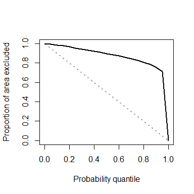

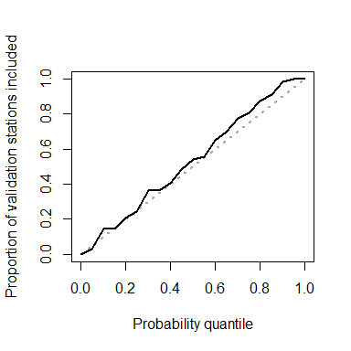

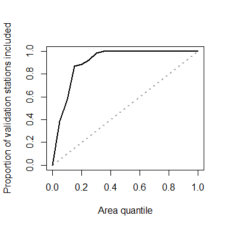

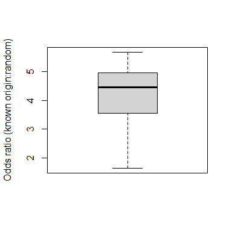

```r
plot(qa1)
```

How would using a different isoscape or different known origin dataset affect the analysis? Multiple QA objects can be compared to make these types of assessments.

Let’s modify our isoscape to add some random noise.

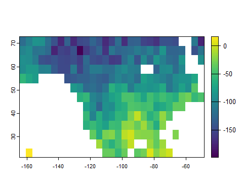

```r
dv = values(d2h_lrNA[[1]])
dv = dv + rnorm(length(dv), 0, 15)
d2h_fuzzy = setValues(d2h_lrNA[[1]], dv)
plot(d2h_fuzzy)
```

We’ll combine the fuzzy isoscape with the uncertainty layer from the original isoscape, then rerun `QA` using the new version. Obviously this is not something you’d do in real work, but as an example it allows us to ask the question “how would the quality of my assignments change if my isoscape predictions were of reduced quality?”.

```r
d2h_fuzzy = c(d2h_fuzzy, d2h_lrNA[[2]])
qa2 = QA(Ll_d, d2h_fuzzy, valiStation = 8, valiTime = 4, by = 5, mask = naMap, name = "fuzzy")
```

Now we can `plot` to compare.

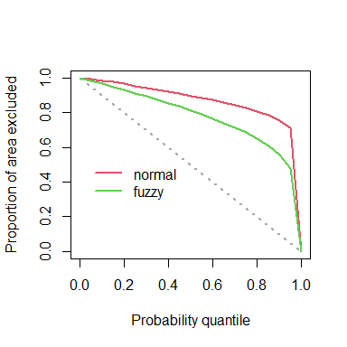

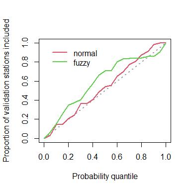

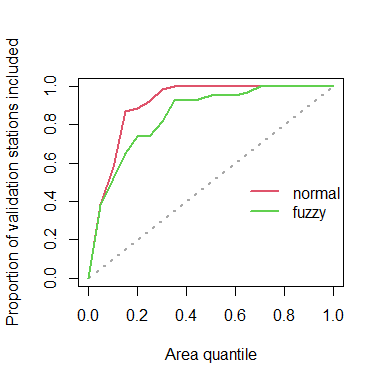

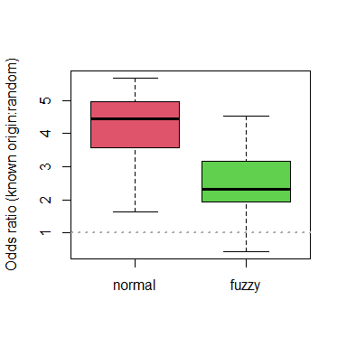

```r
plot(qa1, qa2)
```

Assignments made using the fuzzy isoscape are generally poorer than those made without fuzzing. Hopefully that’s not a surprise, but you might encounter cases where decisions about how to design your project or conduct your data analysis do have previously unknown or unexpected consequences. These types of comparisons can help reveal them!

Questions or comments? gabe.bowen@utah.edu